# Análisis exploratorio de datos

Santiago Jiménez Muriel

24-12-2021

# Práctica

## Librerías

```r
library(dplyr)
library(readxl)
library(tibble)
library(tidyr)
library(ggplot2)
library(corrplot)
library(MASS)
library(reshape2)
library(caret)
library(ggmosaic)
library(car)
library(lmtest)
```

## Introducción

Se pretende identificar ineficiencias en el proceso de venta o factores internos y externos que pueden estar impactando el rendimiento de las mismas de una empresa de dispositivos electrónicos para las franquicias de todo el país.

Las variables son las siguientes:

1. Rentabieco = Rentabilidad económica
2. Rentabifin = Rentabilidad financier
3. Endp = Nivel de endeudamiento de las franquicias que venden estos dispositivos, valorado en euros
4. Liq = Liquidez monetaria de las franquicias
5. Productividad = ratio. Buscar la relación que puede tener con otras variables.
6. Coe = cuota de mercado
7. Edad = tiempo que llevan las franquicias operando
8. Conce = número de entidades que dan este mismo servicio a nivel municipio
9. Numac = nº accionistas
10. Numpa = nº participados
11. Numest = nº establecimientos por empresa
12. Estp = nº establecimientos en otras provincias

## Ejercicio 0

Cargamos nuestros datos en un dataframe para poder analizarlo.

```r
data <- read_xlsx("DatosPractica.xlsx")
```

Realizamos un análisis previo de nuestros datos para conocer las variables.

```r
glimpse(data)
```

```
## Rows: 4,403
## Columns: 18
## $ REGISTRO              <dbl> 1, 2, 3, 4, 5, 6, 7, 8, 9, 10, 11, 12, 13, 14, 1~
## $ PROVINCIA             <chr> "Albacete", "Albacete", "Albacete", "Albacete", ~
## $ rentabieco            <dbl> 0.859980, -4.747951, -0.322200, 12.989917, 1.460~
## $ rentabifin            <dbl> 8.395600, -20.148327, -1.934790, 28.382090, 55.7~
## $ endp                  <dbl> 89.75678, 76.43501, 83.34703, 54.23199, 97.37948~
## $ liq                   <dbl> 1.101604, 1.308301, 0.853852, 1.577194, 1.009258~
## $ PRODUCTIVIDAD         <dbl> 114.918892, 146.386673, 11.743305, 19.276188, 36~
## $ VENTAS                <dbl> 1269.829, 338.338, 17715.250, 20847.926, 1238.50~
## $ `NÚMERO DE EMPLEADOS` <dbl> 1, 1, 46, 40, 2, 54, 1, 2, 8, 2, 18, 1, 6, 4, 1,~
## $ coe                   <dbl> 0.0049253717, 0.0013123345, 0.0687133406, 0.0808~
## $ edad                  <dbl> 2, 8, 25, 24, 2, 40, 10, 11, 10, 15, 13, 10, 7, ~
## $ conce                 <dbl> 9, 9, 34, 34, 3, 34, 34, 34, 9, 34, 34, 34, 3, 3~
## $ numac                 <dbl> 1, 0, 3, 3, 0, 1, 1, 1, 3, 0, 4, 0, 2, 2, 0, 1, ~
## $ numpa                 <dbl> 0, 0, 0, 0, 0, 0, 0, 0, 0, 0, 1, 0, 0, 0, 0, 2, ~
## $ numest                <dbl> 1, 1, 2, 2, 2, 7, 1, 1, 1, 2, 2, 1, 1, 1, 1, 8, ~
## $ estp                  <dbl> 0, 0, 0, 0, 0, 1, 0, 0, 0, 0, 0, 0, 0, 0, 0, 1, ~
## $ grupo                 <dbl> 0, 0, 0, 0, 0, 0, 0, 0, 0, 0, 0, 0, 0, 0, 0, 0, ~
## $ fju                   <dbl> 0, 0, 1, 1, 0, 1, 0, 0, 1, 1, 0, 0, 0, 0, 0, 1, ~
```

Se observa una variable categórica, la cual reúne las distintas provincias españolas, por lo que se procede a transformarlas en factores agrupandolas por comunidades. Asi mismo, se elimina la variable **registro**, puesto que no interesa para el análisis.

```r
data$PROVINCIA <- factor(data$PROVINCIA,
                         levels= c("Álava","Albacete","Alicante","Almería","Asturias","Ávila","Badajoz","Baleares","Barcelona","Burgos","Cáceres","Cádiz","Cantabria","Castellón","CEUTA","Ciudad Real","Córdoba","Cuenca","Gerona","Granada","Guadalajara","Guipúzcoa","Huelva","Huesca","Jaén","La Coruña","Las Palmas","León","Lérida","Logroño","Lugo","Madrid","Málaga","MELILLA","Murcia","Navarra","Orense","Palencia","Pontevedra","Salamanca","Segovia","Sevilla","Soria","Sta. Cruz de Tenerife","Tarragona","Teruel","Toledo","Valencia","Valladolid","Vizcaya","Zamora","Zaragoza"),
                          labels=  c("País Vasco","Castilla la Mancha","Valencia","Andalucía","Asturias","Castilla y León","Extremadura","Islas Baleares","Cataluña","Castilla y León","Extremadura","Andalucía","Cantabria","Valencia","Ceuta","Castilla la Mancha","Andalucía","Castilla la Mancha","Cataluña","Andalucía","Castilla la Mancha","País Vasco","Andalucía","Aragón","Andalucía","Galicia","Islas Canarias","Castilla y León","Cataluña","La Rioja","Galicia","Madrid","Andalucía","Melilla","Murcia","Navarra","Galicia","Castilla y León","Galicia","Castilla y León","Castilla y León","Andalucía","Castilla y León","Islas Canarias","Cataluña","Aragón","Castilla la Mancha","Valencia","Castilla y León","País Vasco","Castilla y León","Aragón"))

data$REGISTRO = NULL
```

## Ejercicio 1

### Análisis descriptivo. Estudiar la distribución de las variables, así como detectar posibles valores atípicos o relaciones

Comenzaremos con un resumen del comportamiento de nuestros datos.

```r
summary(data)
```

```
##            PROVINCIA      rentabieco          rentabifin            endp
##  Cataluña       : 822   Min.   :-179.7045   Min.   :-459.480   Min.   :  0.00
##  Andalucía      : 661   1st Qu.:   0.1294   1st Qu.:   2.658   1st Qu.: 61.21
##  Valencia       : 527   Median :   1.7748   Median :  10.671   Median : 79.15
##  Madrid         : 473   Mean   :   0.7648   Mean   :  16.198   Mean   : 79.53
##  Galicia        : 314   3rd Qu.:   4.8275   3rd Qu.:  24.988   3rd Qu.: 93.25
##  Castilla y León: 288   Max.   :  48.4145   Max.   : 494.178   Max.   :433.21
##  (Other)        :1318
##       liq            PRODUCTIVIDAD         VENTAS         NÚMERO DE EMPLEADOS
##  Min.   :  0.01527   Min.   : -1.172   Min.   :    4.92   Min.   :  1.00
##  1st Qu.:  0.94691   1st Qu.:  5.085   1st Qu.:  494.89   1st Qu.:  3.00
##  Median :  1.15317   Median : 11.755   Median : 1592.14   Median :  7.00
##  Mean   :  1.90566   Mean   : 16.224   Mean   : 6648.16   Mean   : 16.34
##  3rd Qu.:  1.54464   3rd Qu.: 18.783   3rd Qu.: 7819.91   3rd Qu.: 21.00
##  Max.   :113.15031   Max.   :268.593   Max.   :77055.79   Max.   :169.00
##
##       coe                 edad           conce           numac
##  Min.   :0.0000012   Min.   : 0.00   Min.   :  1.0   Min.   : 0.000
##  1st Qu.:0.0004909   1st Qu.: 5.00   1st Qu.:  4.0   1st Qu.: 0.000
##  Median :0.0021491   Median :11.00   Median : 11.0   Median : 1.000
##  Mean   :0.0118101   Mean   :12.29   Mean   : 29.8   Mean   : 1.228
##  3rd Qu.:0.0106936   3rd Qu.:18.00   3rd Qu.: 28.0   3rd Qu.: 2.000
##  Max.   :0.5060498   Max.   :49.00   Max.   :215.0   Max.   :17.000
##
##      numpa             numest            estp             grupo
##  Min.   : 0.0000   Min.   : 1.000   Min.   :0.00000   Min.   :0.00000
##  1st Qu.: 0.0000   1st Qu.: 1.000   1st Qu.:0.00000   1st Qu.:0.00000
##  Median : 0.0000   Median : 1.000   Median :0.00000   Median :0.00000
##  Mean   : 0.1687   Mean   : 1.714   Mean   :0.03157   Mean   :0.05428
##  3rd Qu.: 0.0000   3rd Qu.: 2.000   3rd Qu.:0.00000   3rd Qu.:0.00000
##  Max.   :20.0000   Max.   :34.000   Max.   :1.00000   Max.   :1.00000
##
##       fju
##  Min.   :0.0000
##  1st Qu.:0.0000
##  Median :0.0000
##  Mean   :0.2775
##  3rd Qu.:1.0000
##  Max.   :1.0000
##
```

Queremos conocer si las variables siguen una distribución normal. Para ello, realizarmos una prueba de Shapiro-Wilks a todo el dataset. Debido a que kas comunidades autónomas no son numéricas, se procede a eliminar la variable temporalmente.

```r
data$PROVINCIA = NULL
apply(data,2,shapiro.test)
```

```
## $rentabieco
##
##  Shapiro-Wilk normality test
##
## data:  newX[, i]
## W = 0.62281, p-value < 2.2e-16
##
##
## $rentabifin
##
##  Shapiro-Wilk normality test
##
## data:  newX[, i]
## W = 0.67036, p-value < 2.2e-16
##
##
## $endp
##
##  Shapiro-Wilk normality test
##
## data:  newX[, i]
## W = 0.81696, p-value < 2.2e-16
##
##
## $liq
##
##  Shapiro-Wilk normality test
##
## data:  newX[, i]
## W = 0.17047, p-value < 2.2e-16
##
##
## $PRODUCTIVIDAD
##
##  Shapiro-Wilk normality test
##
## data:  newX[, i]
## W = 0.58933, p-value < 2.2e-16
##
##
```

[output cut: 71 more lines]

```
##
## $grupo
##
##  Shapiro-Wilk normality test
##
## data:  newX[, i]
## W = 0.23605, p-value < 2.2e-16
##
##
## $fju
##
##  Shapiro-Wilk normality test
##
## data:  newX[, i]
## W = 0.56029, p-value < 2.2e-16
```

Ninguna variable muestra un p-valor superior a 0.05 , por lo que se rechaza la hipótesis nula y se determina que ninguna variable presenta una distribución normal. A continuación, se realizará una matriz de gráficos que incluirá el histograma de todas las variables, para conocer su distribución y observar su comportamiento.

```r
d <- melt(data)
```

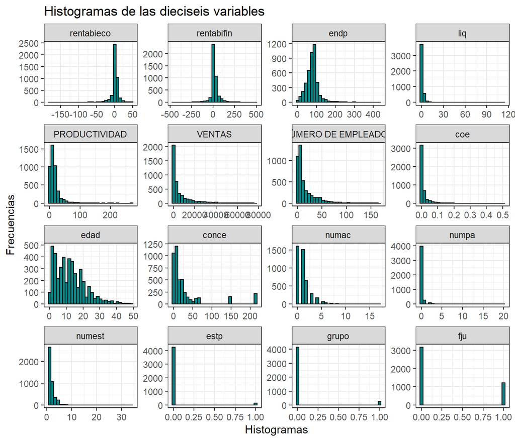

```r
ggplot(d,aes(x = value)) +
  facet_wrap(~variable,scales = "free") +
  geom_histogram(fill = "cyan4",col="black") +
  labs(x = "Histogramas", y = "Frecuencias", title= "Histogramas de las dieciseis variables")+
  theme_bw()
```

Se observan que algunas variables presentan una distribución no simétrica, con una gran varianza de los datos, con valores muy concentrados en el lado izquierdo. Para obtener unos nuevos datos que sigan una distribucion normal, se realiará una transformacion logistica a ciertas variables. Se procede a crear nuevas columnas con las variables transformadas sin eliminar las originales, además de plasmarlos en un gráfico.

```r
data$lognumpa <- log1p(data$numpa)
data$logventas <- log1p(data$VENTAS)#
data$logempleados <- log1p(data$`NÚMERO DE EMPLEADOS`)
data$logproduc <- abs(log1p(data$PRODUCTIVIDAD))#
data$logcoe <- log1p(data$coe)#
data$logliq <- log1p(data$liq) #
data$lognumest <- log1p(data$numest)
data$logedad <- log1p(data$edad)#
data$logconce <- log1p(data$conce)
data$lognumac <- log1p(data$numac)
data$logendp <- log1p(data$endp)

d <- melt(data[17:27])
```

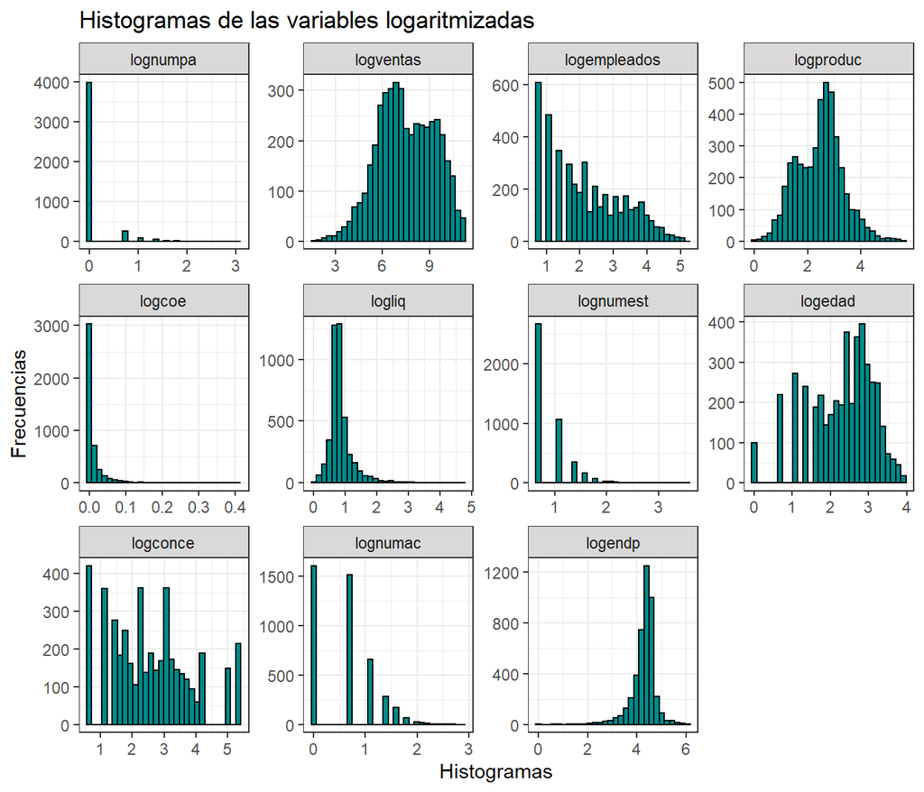

```r
ggplot(d,aes(x = value)) +
  facet_wrap(~variable,scales = "free") +
  geom_histogram(fill = "cyan4",col="black") +
  labs(x = "Histogramas", y = "Frecuencias", title= "Histogramas de las variables logaritmizadas")+
  theme_bw()
```

```r
data$lognumpa <- NULL
data$logventas <- NULL
data$logempleados <- NULL
data$logproduc <- NULL
data$logcoe <- NULL
data$logliq <- NULL
data$lognumest <- NULL
data$logedad <- NULL
data$logconce <- NULL
data$lognumac <-NULL
data$logendp <- NULL
```

Pasamos a analizar las correlaciones existentes en los datos. Para ello, se utiliza la función corrplot para crear una ilustración en la que se observará el nivel de correlacion entre cada variable asignada a un color. Asi mismo, se ha añadido el p-valor de cada relación, para conocer el grado de significación entre las variables, las cuales están representadas por asteriscos.

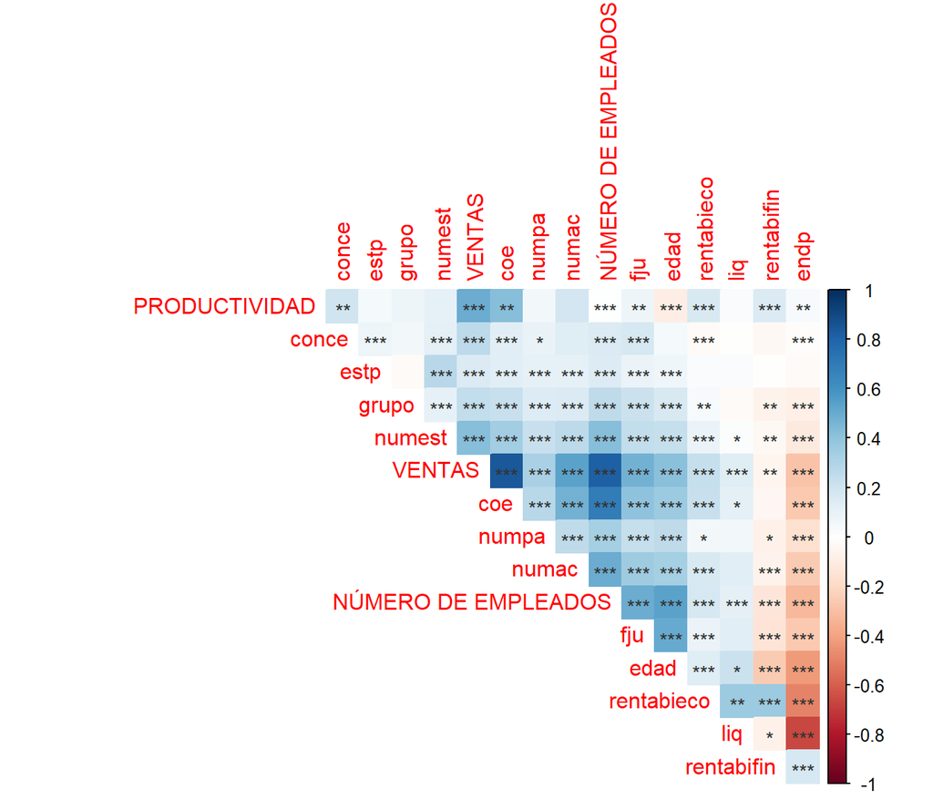

```r
correlacion <- cor(data,method = "spearman")

pvalor= cor.mtest(data,conf.level=0.95)

corrplot(correlacion, p.mat = pvalor$p, method = 'color', diag = FALSE, type = 'upper',
         sig.level = c(0.001, 0.01, 0.05), pch.cex = 0.9,
         insig = 'label_sig', pch.col = 'grey20', order = 'AOE')
```

Se observa una serie de correlaciones bastante intensas entre varias variables. Las **ventas** correlacionan muy significativamente con la **cuota de mercado**, el **numero de empleados** y el **número de accionistas**. Asi mismo, la **liquidez monetaria** de las franquicias esta inversamente correlacionada con el **nivel de endeudamiento** de las franquicias. Asi mismo, el **número de empleados** tiene una relación intensa y bastante significativa con la **cuota de mercado**. Esta última relación deberá ser tomada en cuenta para la creación de un modelo predictivo. Finalmente, el **nivel de endeudamiento** presenta una correlación inversa moderadamente intensa con la *edad* y la *rentabilidad económica**.

## Ejercicio 2

### Análisis del Comportamiento de las Ventas y Variables que le Afectan.

Para analizar la variable ventas, procedermos a utilizar la variable con una transformación logarítmica, para comprender mejor su distribución.

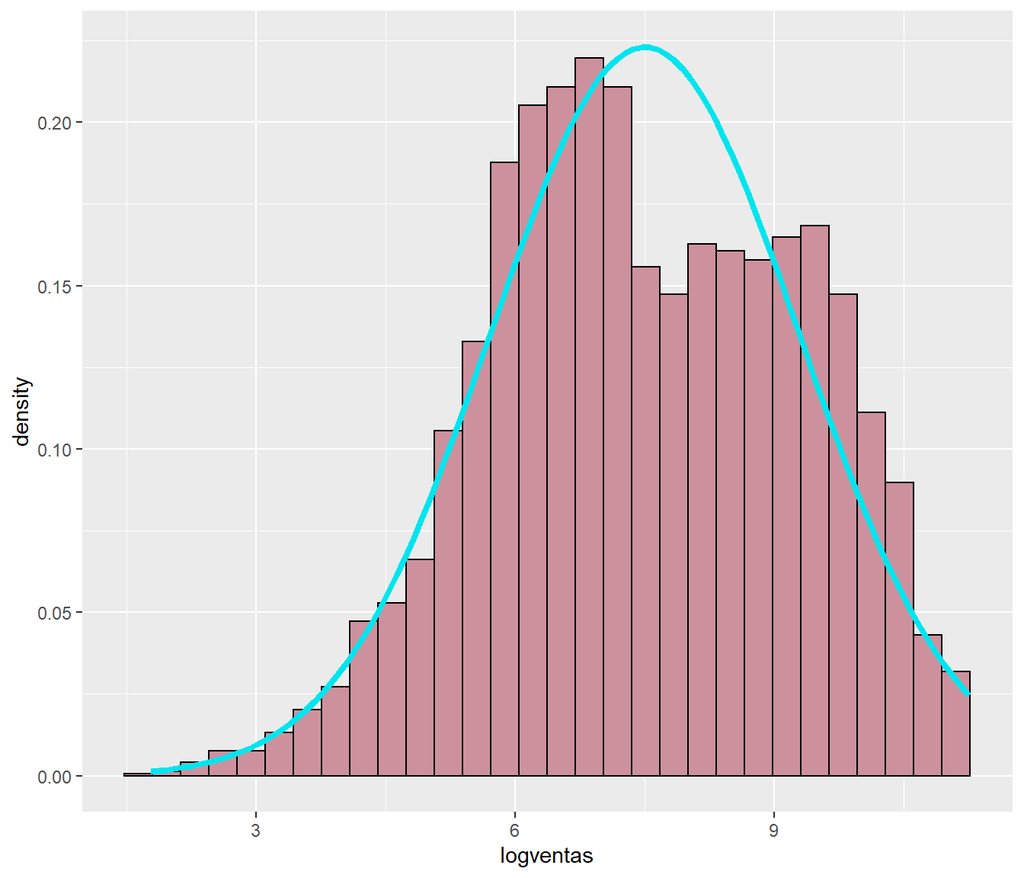

```r
data$logventas <- log1p(data$VENTAS)

ggplot(data=data, aes(x = logventas))   + geom_histogram(aes(y=..density..),fill="pink3",col = "black") +
  stat_function(fun = dnorm,color= "turquoise2", size=1.5, args = list(mean = mean(data$logventas), sd = sd(data$logventas)))
```

La variable presenta una distribución parecida a la normal, con menor número de ventas por la parte central.

Se procede a observar el **número de ventas** por **comunidades**. Para ello, se utilizará la variable **provincia** factorizada en comunidades, realizado previamente. Para menor sobrecarga del gráfico, se eliminirá momentáneamente la variable **ventas** para utilizar su logaritmo.

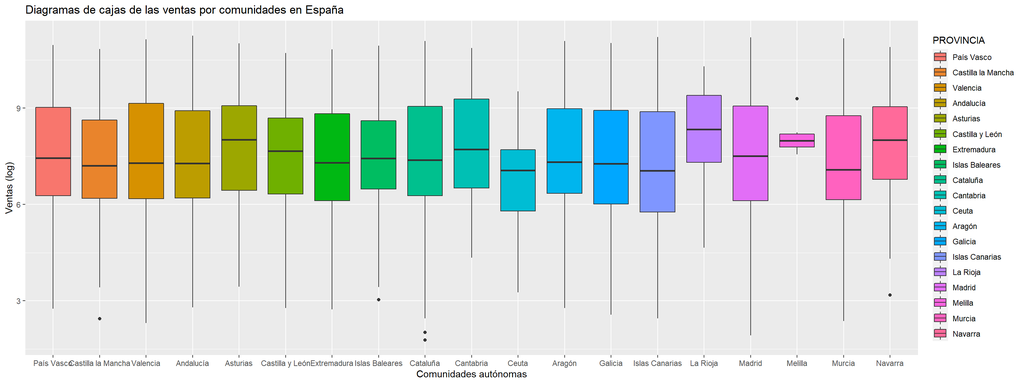

```r
data <- read_xlsx("DatosPractica.xlsx")
data$REGISTRO = NULL
data$logventas <- log1p(data$VENTAS)
data$PROVINCIA <- factor(data$PROVINCIA,
                         levels= c("Álava","Albacete","Alicante","Almería","Asturias","Ávila","Badajoz","Baleares","Barcelona","Burgos","Cáceres","Cádiz","Cantabria","Castellón","CEUTA","Ciudad Real","Córdoba","Cuenca","Gerona","Granada","Guadalajara","Guipúzcoa","Huelva","Huesca","Jaén","La Coruña","Las Palmas","León","Lérida","Logroño","Lugo","Madrid","Málaga","MELILLA","Murcia","Navarra","Orense","Palencia","Pontevedra","Salamanca","Segovia","Sevilla","Soria","Sta. Cruz de Tenerife","Tarragona","Teruel","Toledo","Valencia","Valladolid","Vizcaya","Zamora","Zaragoza"),
                          labels=  c("País Vasco","Castilla la Mancha","Valencia","Andalucía","Asturias","Castilla y León","Extremadura","Islas Baleares","Cataluña","Castilla y León","Extremadura","Andalucía","Cantabria","Valencia","Ceuta","Castilla la Mancha","Andalucía","Castilla la Mancha","Cataluña","Andalucía","Castilla la Mancha","País Vasco","Andalucía","Aragón","Andalucía","Galicia","Islas Canarias","Castilla y León","Cataluña","La Rioja","Galicia","Madrid","Andalucía","Melilla","Murcia","Navarra","Galicia","Castilla y León","Galicia","Castilla y León","Castilla y León","Andalucía","Castilla y León","Islas Canarias","Cataluña","Aragón","Castilla la Mancha","Valencia","Castilla y León","País Vasco","Castilla y León","Aragón"))

#Diagrama de cajas de ventas por comunidades
ggplot(data= data, aes(x = PROVINCIA, y = logventas,  fill = PROVINCIA)) +
  geom_boxplot() +
  labs(title = "Diagramas de cajas de las ventas por comunidades en España",x = "Comunidades autónomas" ,y = "Ventas (log)")
```

```r
kruskal.test(logventas ~ PROVINCIA, data)
```

```
##
##  Kruskal-Wallis rank sum test
##
## data:  logventas by PROVINCIA
## Kruskal-Wallis chi-squared = 22.502, df = 18, p-value = 0.2104
```

Debido a que el p-valor es bastante superior a 0.05, se acepta la hipótesis nula y se establece que **no existen difencias significativas** entre las comunidades en función de las ventas.

Observemos las correlaciones existentes entre las **ventas** y el resto de variables. Si bien se ha estudiado previamente las correlaciones del resto de variables, crearemos una figura que muestré el nivel de correlación exacto.

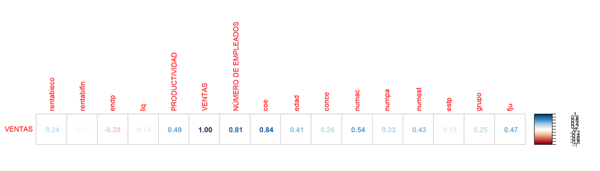

```r
corrplot(correlacion[6,,drop=FALSE], method= "number")
```

Se observan correlaciones elevadas con la **productividad**, el **número de empleados**, la **cuota de mercado**,la **edad**, el **número de accionistas**, el **número de establecimientos por empresa** y el fju. Debido a que no conocemos información sobre esta útlima variable, no se realizará análisis sobre ella, si bien se observa que las empresas que tienen un **fju** de 1 tienen mayor número de ventas que aquellas que tienen un 0.

Pasemos a estudiar la relación existente entre las variables mencionadas y las ventas. Para ello utilizaremos un diagrama de dispersión acompañado de una curva que muestra el comportamiento de la correlación.Para las variables **productividad**, **cuota de mercado**, **edad** y **número de accionistas** se aplicará una transformación logarítmica.

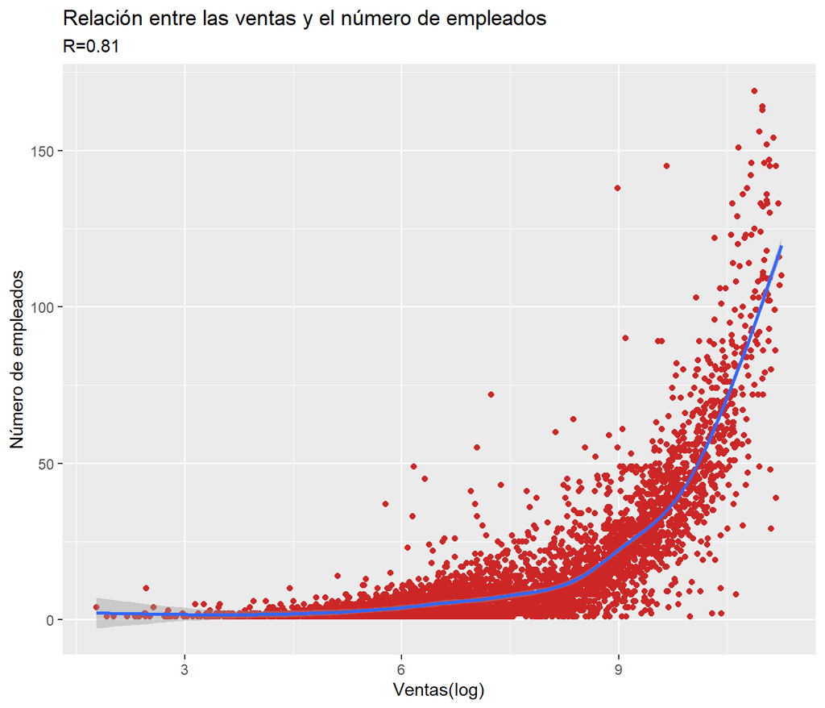

```r
ggplot(data = data, aes(x=logventas,y=`NÚMERO DE EMPLEADOS`)) +
  geom_point(col="firebrick3")+
  geom_smooth() +
  labs(title= "Relación entre las ventas y el número de empleados",x="Ventas(log)",y = "Número de empleados", subtitle = "R=0.81")
```

La relación entre ambas variables es bastante significativa, aumentando ampliamente el número de ventas conforme la empresa tiene un mayor número de empleados.

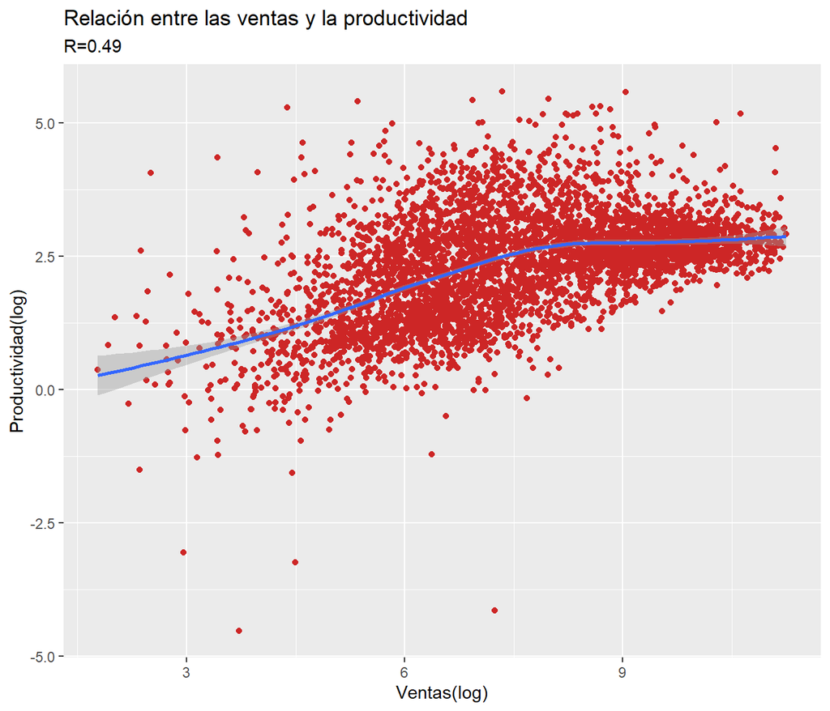

```r
ggplot(data = na.omit(data), aes(x=logventas,y=log(PRODUCTIVIDAD))) +
  geom_point(col="firebrick3")+
  labs(title= "Relación entre las ventas y la productividad",x="Ventas(log)",y = "Productividad(log)", subtitle = "R=0.49") +
  theme_grey() +
  geom_smooth()
```

Se ha utilizado el logaritmo de la productividad para observar la relación. Se observa que las ventas tienden a estabilizarse llegados a un punto conforme aumenta la productividad. Sin embargo, el aumento de ventas en función de la productividad es creciente.

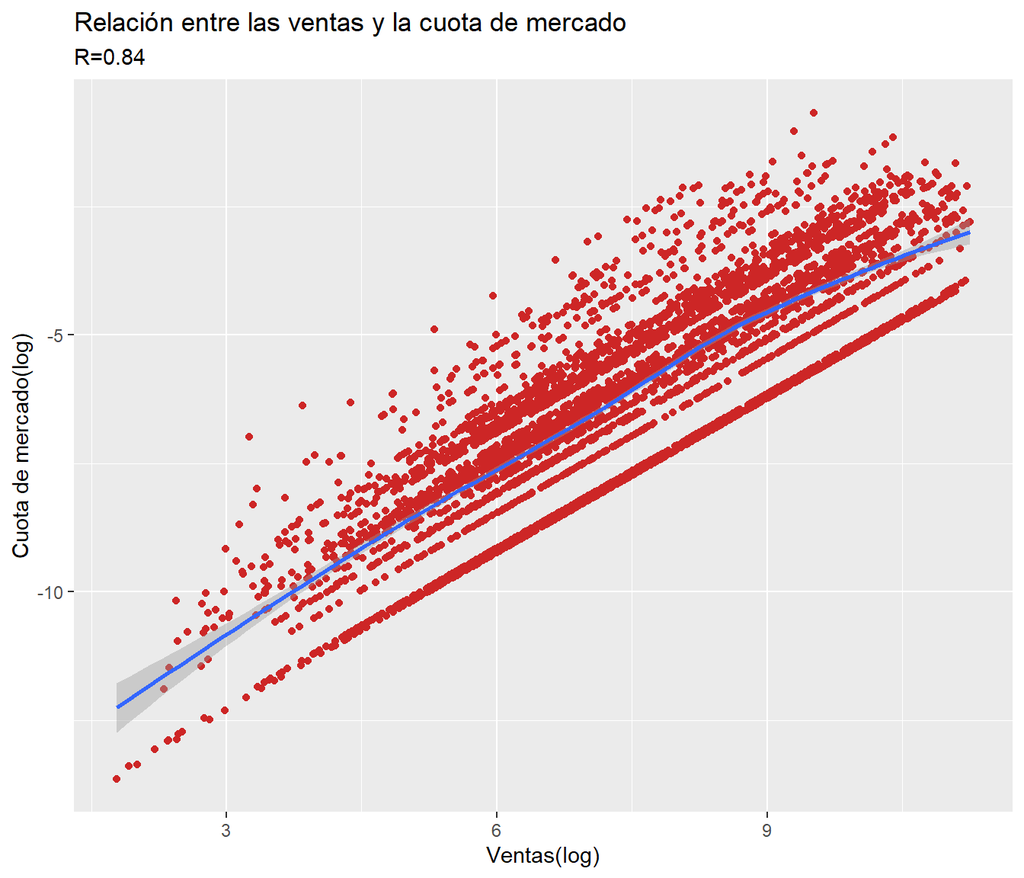

```r
ggplot(data = data, aes(x=logventas,y=log(coe))) +
  geom_point(col="firebrick3")+
  labs(title= "Relación entre las ventas y la cuota de mercado",x="Ventas(log)",y = "Cuota de mercado(log)", subtitle = "R=0.84") +
  theme_grey() +
  geom_smooth()
```

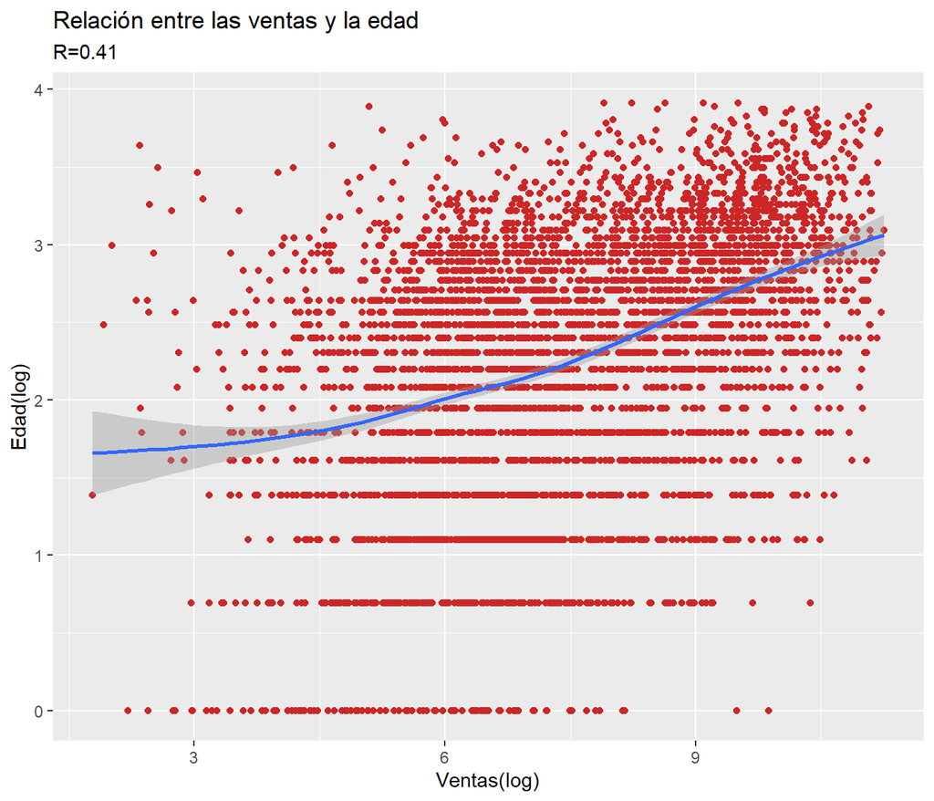

```r
ggplot(data = data, aes(x=logventas,y=log1p(edad))) +
  geom_point(col="firebrick3")+
  labs(title= "Relación entre las ventas y la edad",x="Ventas(log)",y = "Edad(log)", subtitle = "R=0.41") +
  theme_grey() +
  geom_smooth()
```

Se observa una tendencia a presentar mayor número de ventas en aquellas empresas que son mas antigüas, concentrandose las ventas en las empresas mas longevas.

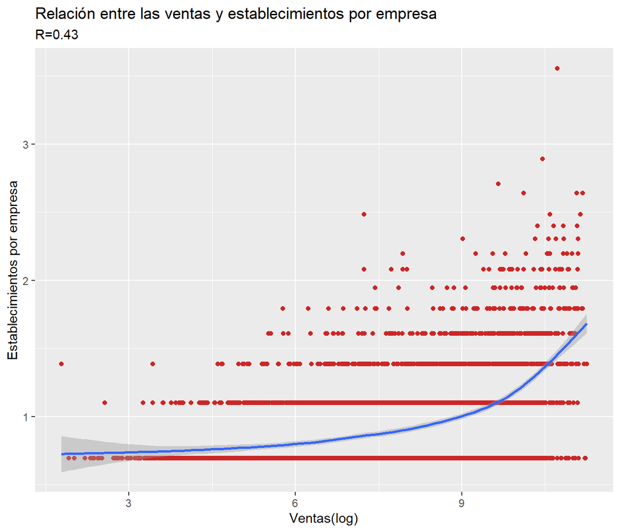

```r
ggplot(data = data, aes(x=logventas,y=log1p(numest))) +
  geom_point(col="firebrick3")+
  labs(title= "Relación entre las ventas y establecimientos por empresa",x="Ventas(log)",y = "Establecimientos por empresa", subtitle = "R=0.43") +
  theme_grey() +
  geom_smooth()
```

La relación es muy significativa, presentando un volumen mucho mayor de ventas en aquellas empresas que tienen mayor número de establecimientos. Sin embargo, se puede observar que los valores se concentran mucho en aquellas empresas con un número reducido de establecimientos.

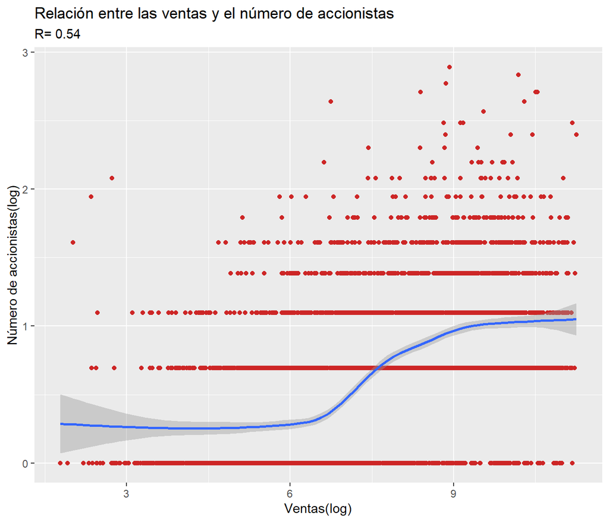

```r
ggplot(data = data, aes(x=logventas,y=log1p(numac))) +
  geom_point(col="firebrick3")+
  labs(title= "Relación entre las ventas y el número de accionistas",x="Ventas(log)",y = "Número de accionistas(log)", subtitle = "R= 0.54") +
  theme_grey() +
  geom_smooth()
```

Debido al número reducido de accionistas de la mayoría de empresar, la mayor parte de las ventas se concentra en aquellas que poseen un número menor de accionistas. A pesar de que se observa que a mayor número de accionistas aumentan las ventas, se detecta un posible estancamiento del crecimiento de las ventas.

## Ejercicio 3

### Realizar una tabla de contingencia entre Ventas y Número de empleados, una vez categorizadas ambas variables, para número de empleados, por ejemplo, la utilizada a nivel Europeo, la cual divide a las empresas en Microempresas (1-9 trabajadores), Pequeña empresa (10-49 trabajadores), Mediana empresa (50-249 trabajadores) y Gran empresa (250 y más trabajadores)).

Realizamos la transformación de la variable **número de empleados** según se indica.

```r
data$Tipo_empresa <- cut(data$`NÚMERO DE EMPLEADOS`, breaks = c(0, 9, 49, 249, Inf),
                        labels = c("Microempresas (0-9)", "Pequeña empresa (10-49)", "Mediana empresa (50-249)","Gran empresa (+250)"))
```

A continuación, observamos la distribución de las **ventas** para conocer los posibles valores en los que clasificarlos.

```r
summary(data$VENTAS)
```

```
##     Min.  1st Qu.   Median     Mean  3rd Qu.     Max.
##     4.92   494.89  1592.14  6648.16  7819.91 77055.79
```

Se decide realizar una división en cuatro factores, con los valores que van acorde a los quartiles de la variable. Se dividirá en: *ventas bajas (0-495), ventas bajas-medias (496-1593), ventas medias-altas(1594-7820) y ventas altas (+7821).

```r
data$ventascat <- cut(data$VENTAS, breaks = c(0, 495, 1593, 7820, Inf),
                        labels = c("Ventas bajas", "Ventas bajas.medias", "Ventas medias-altas", "Ventas altas"))
```

Realizamos la tabla de contingencia.

```r
tabla = table(data$ventascat,data$Tipo_empresa)
tabla
```

```
##
##                       Microempresas (0-9) Pequeña empresa (10-49)
##   Ventas bajas                       1078                      23
##   Ventas bajas.medias                 920                     179
##   Ventas medias-altas                 513                     582
##   Ventas altas                         50                     717
##
##                       Mediana empresa (50-249) Gran empresa (+250)
##   Ventas bajas                               0                   0
##   Ventas bajas.medias                        2                   0
##   Ventas medias-altas                        5                   0
##   Ventas altas                             334                   0
```

Para observar mejor la relación entre ambas variables, realizaremos un gráfico de mosaico.

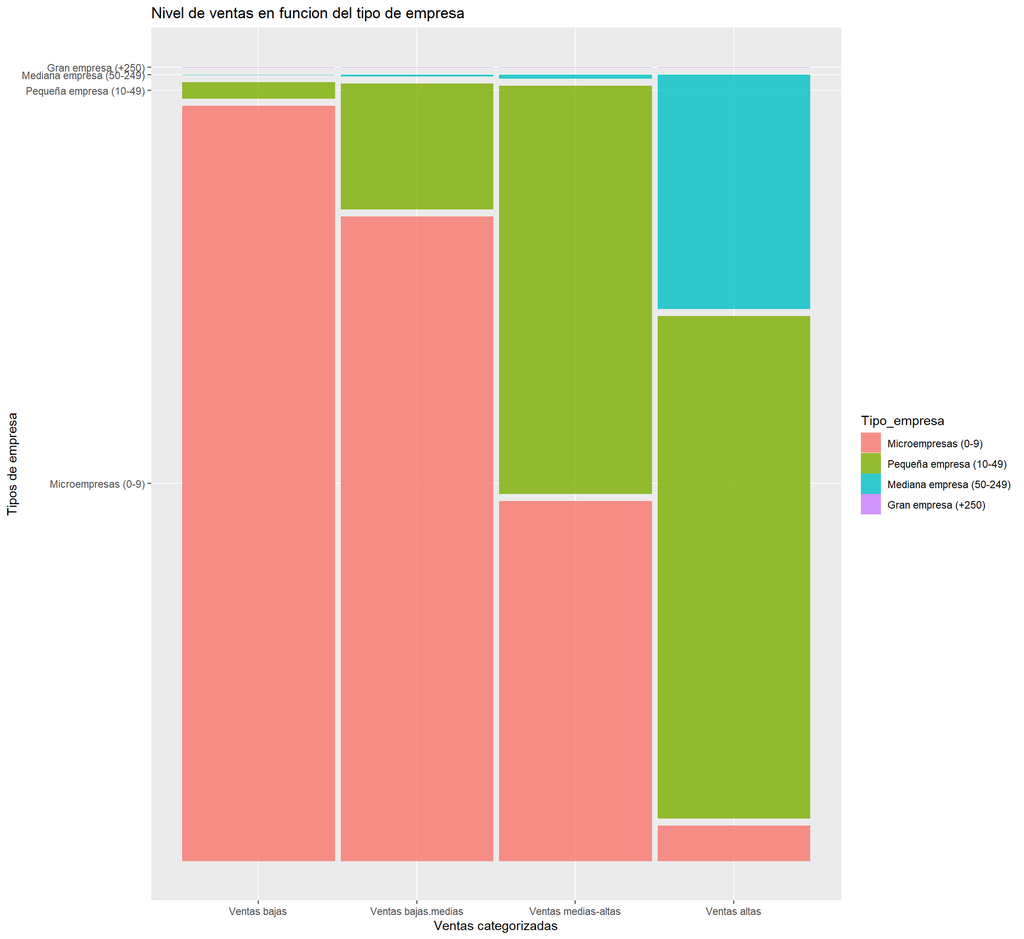

```r
ggplot(data=data, aes(x="Tipo de empresa",y="Ventas categorizadas")) +
  geom_mosaic(aes(x=product(ventascat), fill= Tipo_empresa)) +
  labs(title = "Nivel de ventas en funcion del tipo de empresa", x="Ventas categorizadas", y="Tipos de empresa")
```

Se observa una relación significativa, puesto que el volumen de ventas es mayor en las empresas mas grandes, es decir, las que tienen mas trabajadores. Las **microempresas** concentran la mayor parte de las ventas bajas, mientras que las **pequeñas empresas** concentran sus ventas en las ventas medias-altas y ventas altas, siendo este tipo de empresa quienes tienen mayor número de ventas altas. Las **empresas medianas** realizan casi en exclusiva ventas altas. Finalmente, las **grandes empresas** no aparecen en el conjunto de datos, debido a que no recoge empresas con un número mayor a 250 personas.